# Tugas Pertemuan 2 - Metode Pemulusan Deret Waktu

# 1. Import dan Persiapan Data

Data yang digunakan adalah **suhu maksimum harian Kota Delhi** periode 27 Mei 2023 – 19 Oktober 2023 (146 observasi), data ini merupakan bagian data individu dari gugus data kelompok 2.

```r
library(readxl)
library(TTR)
library(forecast)
library(ggplot2)
```

```r
data <- read_excel("D:\\Documents\\gugus data mpdw kelompok 2.xlsm", sheet = "Sheet1")
data <- na.omit(data)
names(data) <- c("Kota", "Tanggal", "Suhu")
data$Suhu <- as.numeric(data$Suhu)
data$Tanggal <- as.Date(data$Tanggal)
data <- data[order(data$Tanggal), ]

head(data)
```

```
## # A tibble: 6 × 3
##   Kota  Tanggal     Suhu
##   <chr> <date>     <dbl>
## 1 Delhi 2023-05-27  33.0
## 2 Delhi 2023-05-28  33.0
## 3 Delhi 2023-05-29  33.0
## 4 Delhi 2023-05-30  33.0
## 5 Delhi 2023-05-31  30.0
## 6 Delhi 2023-06-01  33
```

```r
n <- nrow(data)
n
```

```
## [1] 146
```

```r
View(data)
str(data)
```

```
## tibble [146 × 3] (S3: tbl_df/tbl/data.frame)
##  $ Kota   : chr [1:146] "Delhi" "Delhi" "Delhi" "Delhi" ...
##  $ Tanggal: Date[1:146], format: "2023-05-27" "2023-05-28" ...
##  $ Suhu   : num [1:146] 33 33 33 33 30 ...
```

```r
dim(data)
```

```
## [1] 146   3
```

```r
data.ts <- ts(data$Suhu)
```

```r
summary(data.ts)
```

```
##    Min. 1st Qu.  Median    Mean 3rd Qu.    Max.
##   28.05   33.00   34.01   34.03   35.08   42.03
```

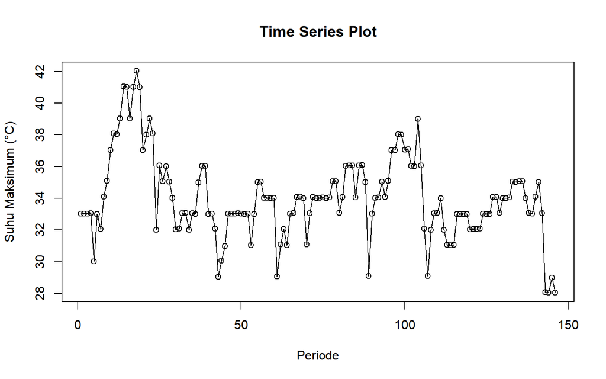

```r
ts.plot(data.ts, xlab="Periode", ylab="Suhu Maksimum (°C)",
        main = "Time Series Plot")
points(data.ts)
```

```r
#menyimpan plot
dev.copy(png, "plot_data.png")
```

```r
dev.off()
```

# 2. Pembagian Data Latih (80%) dan Data Uji (20%)

```r
n_train <- ceiling(0.8 * n)
n_test  <- n - n_train

training <- data$Suhu[1:n_train]
testing  <- data$Suhu[(n_train+1):n]

training.ts <- ts(training, frequency = 7)
testing.ts  <- ts(testing, frequency = 7, start = c(1 + n_train %/% 7, n_train %% 7 + 1))

cat("Total data     :", n, "\n")
```

```
## Total data     : 146
```

```r
cat("Data latih (80%):", n_train, "\n")
```

```
## Data latih (80%): 117
```

```r
cat("Data uji (20%)  :", n_test, "\n")
```

```
## Data uji (20%)  : 29
```

Eksplorasi data dilakukan pada keseluruhan data, data latih serta data uji menggunakan plot data deret waktu.

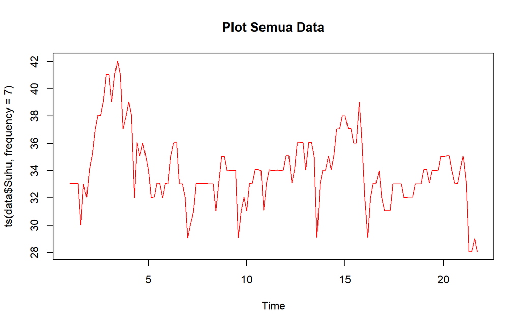

```r
#eksplorasi keseluruhan data
plot(ts(data$Suhu, frequency = 7),
  col = "red",
  main = "Plot Semua Data"
)
```

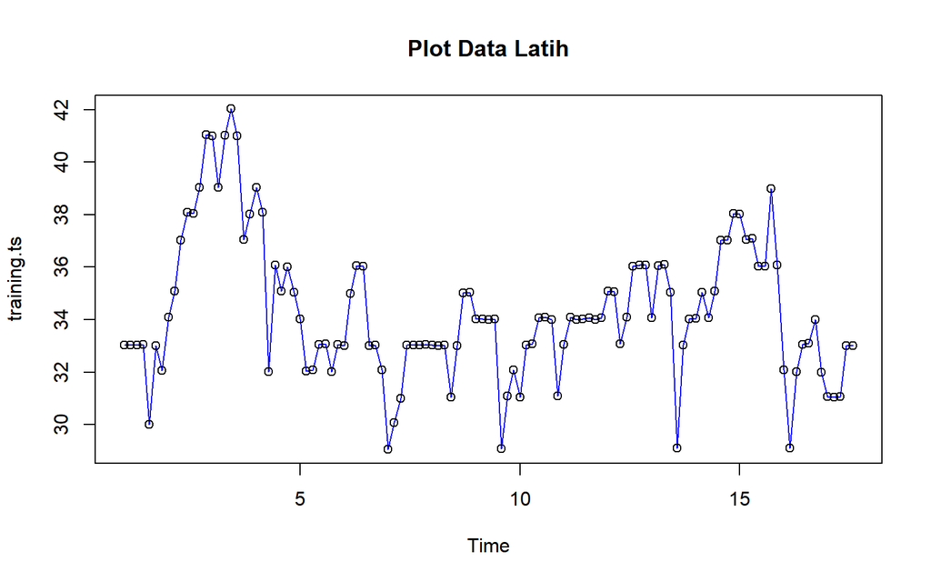

```r
#eksplorasi data latih
plot(
  training.ts,
  col = "blue",
  main = "Plot Data Latih"
)

points(training.ts)
```

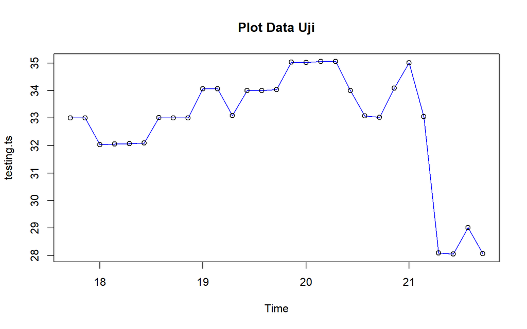

```r
#eksplorasi data uji
plot(
  testing.ts,
  col = "blue",
  main = "Plot Data Uji"
)

points(testing.ts)
```

```r
data_plot <- data.frame(
  Period = 1:n,
  Suhu = data$Suhu,
  Kelompok = c(
    rep("Data Latih", n_train),
    rep("Data Uji", n_test)
  )
)
```

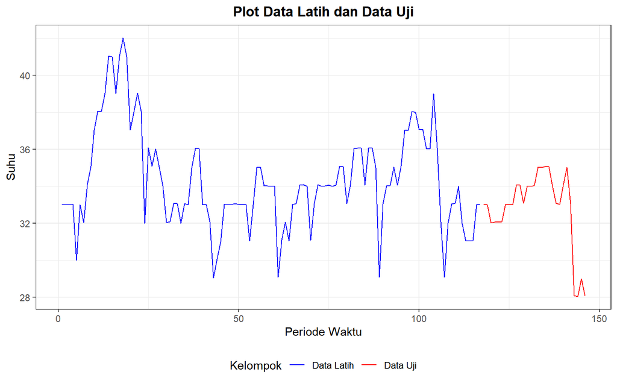

```r
ggplot(data_plot, aes(x = Period, y = Suhu, color = Kelompok)) +
  geom_line() +
  labs(
    x = "Periode Waktu",
    y = "Suhu",
    title = "Plot Data Latih dan Data Uji"
  ) +
  scale_color_manual(
    values = c(
      "Data Latih" = "blue",
      "Data Uji" = "red"
    )
  ) +
  theme_bw() +
  theme(
    legend.position = "bottom",
    plot.title = element_text(
      hjust = 0.5,
      face = "bold"
  )
  )
```

## Single Moving Average (SMA)

Ide dasar dari Single Moving Average (SMA) adalah data suatu periode dipengaruhi oleh data periode sebelumnya. Metode pemulusan ini cocok digunakan untuk pola data stasioner atau konstan. Prinsip dasar metode pemulusan ini adalah data pemulusan pada periode ke-t merupakan rata rata dari m buah data pada periode ke-t hingga periode ke (t-m+1).

$$S_t = \frac{1}{m} \sum_{i=t-m+1}^{t} X_i$$

Data pemulusan pada periode ke-t selanjutnya digunakan sebagai nilai peramalan pada periode ke t+1.

$$F_t = S_{t-1}, F_{n,h} = S_n$$

Pemulusan menggunakan metode SMA dilakukan dengan fungsi `SMA()`. Dalam hal ini akan dilakukan pemulusan dengan parameter `m=4`.

```r
data.sma<-SMA(training.ts, n=4)
data.sma
```

```
##   [1]      NA      NA      NA 33.0350 32.2775 32.2700 32.0275 32.2875 33.5575
##  [10] 34.5650 36.0725 37.0600 38.0475 39.0500 39.7825 40.0300 40.5250 40.7725
##  [19] 40.7700 40.2750 39.5250 38.7775 38.0475 36.7875 36.3025 35.3125 34.7975
##  [28] 35.5575 35.0425 34.2825 33.3000 32.8025 32.5650 32.5575 32.8000 32.7850
##  [37] 33.2675 34.2775 35.0225 35.0250 34.5300 33.5400 31.7925 31.0575 30.5525
##  [46] 30.7875 31.7825 32.5225 33.0375 33.0350 33.0300 33.0300 32.5275 32.5225
##  [55] 33.0250 33.5300 34.2750 34.5325 34.2775 34.0200 32.7825 32.0475 31.5650
##  [64] 30.8200 31.8075 32.3025 32.8025 33.5650 33.8075 33.3100 33.0575 33.0550
##  [73] 33.0575 33.7925 34.0425 34.0250 34.0375 34.3025 34.5525 34.3175 34.3225
##  [82] 34.5625 34.8150 35.5650 35.5600 35.5650 35.5700 35.3100 34.0675 33.3125
##  [91] 32.7950 32.5500 34.0375 34.2950 34.5625 35.3075 35.8050 36.7975 37.5275
## [100] 37.5350 37.5500 37.0500 36.5550 37.0400 36.7875 35.7975 34.0625 32.3150
## [109] 31.5575 31.8100 33.0400 33.0375 32.5400 32.0300 31.2925 31.5425 32.0300
```

Data pemulusan pada periode ke-t selanjutnya digunakan sebagai nilai peramalan pada periode ke t+1 sehingga hasil peramalan 1 periode kedepan adalah sebagai berikut.

```r
data.ramal<-c(NA,data.sma)
data.ramal #forecast 1 periode ke depan
```

```
##   [1]      NA      NA      NA      NA 33.0350 32.2775 32.2700 32.0275 32.2875
##  [10] 33.5575 34.5650 36.0725 37.0600 38.0475 39.0500 39.7825 40.0300 40.5250
##  [19] 40.7725 40.7700 40.2750 39.5250 38.7775 38.0475 36.7875 36.3025 35.3125
##  [28] 34.7975 35.5575 35.0425 34.2825 33.3000 32.8025 32.5650 32.5575 32.8000
##  [37] 32.7850 33.2675 34.2775 35.0225 35.0250 34.5300 33.5400 31.7925 31.0575
##  [46] 30.5525 30.7875 31.7825 32.5225 33.0375 33.0350 33.0300 33.0300 32.5275
##  [55] 32.5225 33.0250 33.5300 34.2750 34.5325 34.2775 34.0200 32.7825 32.0475
##  [64] 31.5650 30.8200 31.8075 32.3025 32.8025 33.5650 33.8075 33.3100 33.0575
##  [73] 33.0550 33.0575 33.7925 34.0425 34.0250 34.0375 34.3025 34.5525 34.3175
##  [82] 34.3225 34.5625 34.8150 35.5650 35.5600 35.5650 35.5700 35.3100 34.0675
##  [91] 33.3125 32.7950 32.5500 34.0375 34.2950 34.5625 35.3075 35.8050 36.7975
## [100] 37.5275 37.5350 37.5500 37.0500 36.5550 37.0400 36.7875 35.7975 34.0625
## [109] 32.3150 31.5575 31.8100 33.0400 33.0375 32.5400 32.0300 31.2925 31.5425
## [118] 32.0300
```

```r
data.gab<-cbind(
  aktual=c(data.ts),
  pemulusan=c(data.sma,rep(NA,29)),
  ramalan=c(data.ramal,rep(data.ramal[length(data.ramal)],29)))

data.gab #forecast 24 periode ke depan
```

```
##        aktual pemulusan ramalan
##   [1,]  33.04        NA      NA
##   [2,]  33.03        NA      NA
##   [3,]  33.02        NA      NA
##   [4,]  33.05   33.0350      NA
##   [5,]  30.01   32.2775 33.0350
##   [6,]  33.00   32.2700 32.2775
##   [7,]  32.05   32.0275 32.2700
##   [8,]  34.09   32.2875 32.0275
##   [9,]  35.09   33.5575 32.2875
##  [10,]  37.03   34.5650 33.5575
##  [11,]  38.08   36.0725 34.5650
##  [12,]  38.04   37.0600 36.0725
##  [13,]  39.04   38.0475 37.0600
##  [14,]  41.04   39.0500 38.0475
```

[output cut: 133 more lines]

Adapun plot data deret waktu dari hasil peramalan yang dilakukan adalah sebagai berikut.

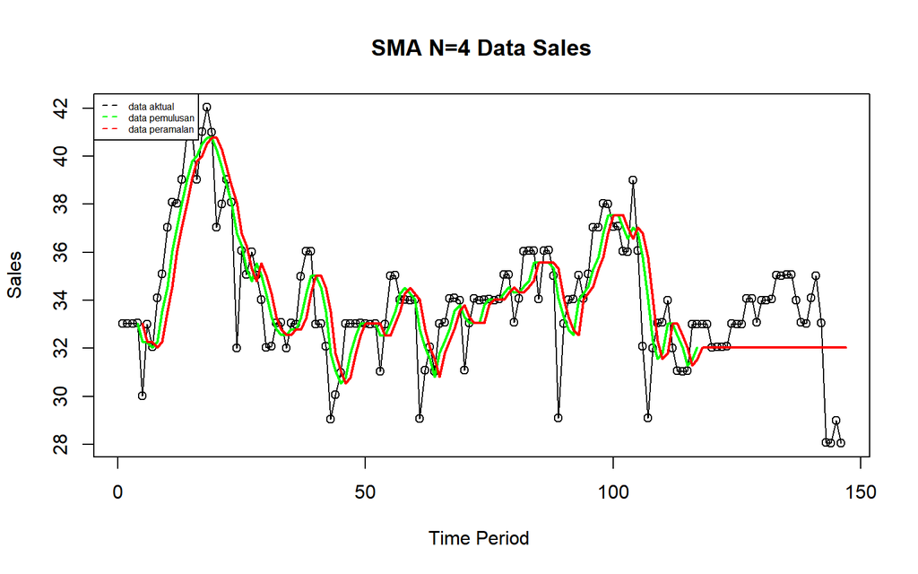

```r
ts.plot(data.ts, xlab="Time Period ", ylab="Sales", main= "SMA N=4 Data Sales")
points(data.ts)
lines(data.gab[,2],col="green",lwd=2)
lines(data.gab[,3],col="red",lwd=2)
legend("topleft",c("data aktual","data pemulusan","data peramalan"), lty=8, col=c("black","green","red"), cex=0.5)
```

Selanjutnya perhitungan akurasi dilakukan dengan ukuran akurasi *Sum Squares Error* (SSE), *Mean Square Error* (MSE) dan *Mean Absolute Percentage Error* (MAPE). Perhitungan akurasi dilakukan baik pada data latih maupun pada data uji.

$$SSE = \sum_{t=1}^{n} (y_t - \hat{y}_t)^2$$
$$MSE = \frac{1}{n} \sum_{t=1}^{n} (y_t - \hat{y}_t)^2$$
$$MAPE = \frac{1}{n} \sum_{t=1}^{n} \left|\frac{y_t -
\hat{y}_t}{y_t}\right| * 100$$

```r
#Menghitung nilai keakuratan data latih
error_train.sma = training.ts-data.ramal[1:length(training.ts)]

SSE_train.sma = sum(error_train.sma[5:length(training.ts)]^2)
MSE_train.sma = mean(error_train.sma[5:length(training.ts)]^2)
MAPE_train.sma = mean(abs((error_train.sma[5:length(training.ts)]/training.ts[5:length(training.ts)])*100))

akurasi_train.sma <- matrix(c(SSE_train.sma, MSE_train.sma, MAPE_train.sma))
row.names(akurasi_train.sma)<- c("SSE", "MSE", "MAPE")
colnames(akurasi_train.sma) <- c("Akurasi m = 4")
akurasi_train.sma
```

```
##      Akurasi m = 4
## SSE     457.701644
## MSE       4.050457
## MAPE      4.535030
```

```r
#Menghitung nilai keakuratan data uji
error_test.sma = testing.ts-data.gab[118:146,3]

SSE_test.sma = sum(error_test.sma^2)
MSE_test.sma = mean(error_test.sma^2)
MAPE_test.sma = mean(abs((error_test.sma/testing.ts*100)))

akurasi_test.sma <- matrix(c(SSE_test.sma, MSE_test.sma, MAPE_test.sma))
row.names(akurasi_test.sma)<- c("SSE", "MSE", "MAPE")
colnames(akurasi_test.sma) <- c("Akurasi m = 4")
akurasi_test.sma
```

```
##      Akurasi m = 4
## SSE     139.011700
## MSE       4.793507
## MAPE      5.684546
```

## Double Moving Average (DMA)

Metode pemulusan Double Moving Average (DMA) pada dasarnya mirip dengan SMA. Namun demikian, metode ini lebih cocok digunakan untuk pola data trend. Proses pemulusan dengan rata rata dalam metode ini dilakukan sebanyak 2 kali.

- **Tahap I:**

$$S_{1,t} = \frac{1}{m} \sum_{i=t-m+1}^{t} X_i$$

- **Tahap II:**

$$S_{2,t} = \frac{1}{m} \sum_{i=t-m+1}^{t} S_{1,i}$$
Forecast $h$ langkah ke depan dihitung dengan:

$$F_{2,t,t+h} = A_t + B_t \,(h)$$

dengan komponen level ($A_t$) dan tren ($B_t$):

$$A_t = 2S_{1,t} - S_{2,t}
\qquad\text{dan}\qquad
B_t = \frac{2}{m-1}\,\big(S_{1,t} - S_{2,t}\big)$$

```r
dma <- SMA(data.sma, n = 4)
At <- 2*data.sma - dma
Bt <- 2/(4-1)*(data.sma - dma)
data.dma<- At+Bt
data.ramal2<- c(NA, data.dma)

t = 1:29
f = c()

for (i in t) {
  f[i] = At[length(At)] + Bt[length(Bt)]*(i)
}

data.gab2 <- cbind(aktual = c(data.ts),
                   pemulusan1 = c(data.sma,rep(NA,29)),
                   pemulusan2 = c(dma, rep(NA,29)),
                   At = c(At, rep(NA,29)),
                   Bt = c(Bt,rep(NA,29)),
                   ramalan = c(data.ramal2, f[-1]))
data.gab2
```

```
##        aktual pemulusan1 pemulusan2       At           Bt  ramalan
##   [1,]  33.04         NA         NA       NA           NA       NA
##   [2,]  33.03         NA         NA       NA           NA       NA
##   [3,]  33.02         NA         NA       NA           NA       NA
##   [4,]  33.05    33.0350         NA       NA           NA       NA
##   [5,]  30.01    32.2775         NA       NA           NA       NA
##   [6,]  33.00    32.2700         NA       NA           NA       NA
##   [7,]  32.05    32.0275   32.40250 31.65250 -0.250000000       NA
##   [8,]  34.09    32.2875   32.21562 32.35937  0.047916667 31.40250
##   [9,]  35.09    33.5575   32.53562 34.57937  0.681250000 32.40729
##  [10,]  37.03    34.5650   33.10938 36.02062  0.970416667 35.26062
##  [11,]  38.08    36.0725   34.12062 38.02437  1.301250000 36.99104
##  [12,]  38.04    37.0600   35.31375 38.80625  1.164166667 39.32562
##  [13,]  39.04    38.0475   36.43625 39.65875  1.074166667 39.97042
##  [14,]  41.04    39.0500   37.55750 40.54250  0.995000000 40.73292
```

[output cut: 132 more lines]

Hasil pemulusan menggunakan metode DMA divisualisasikan sebagai berikut

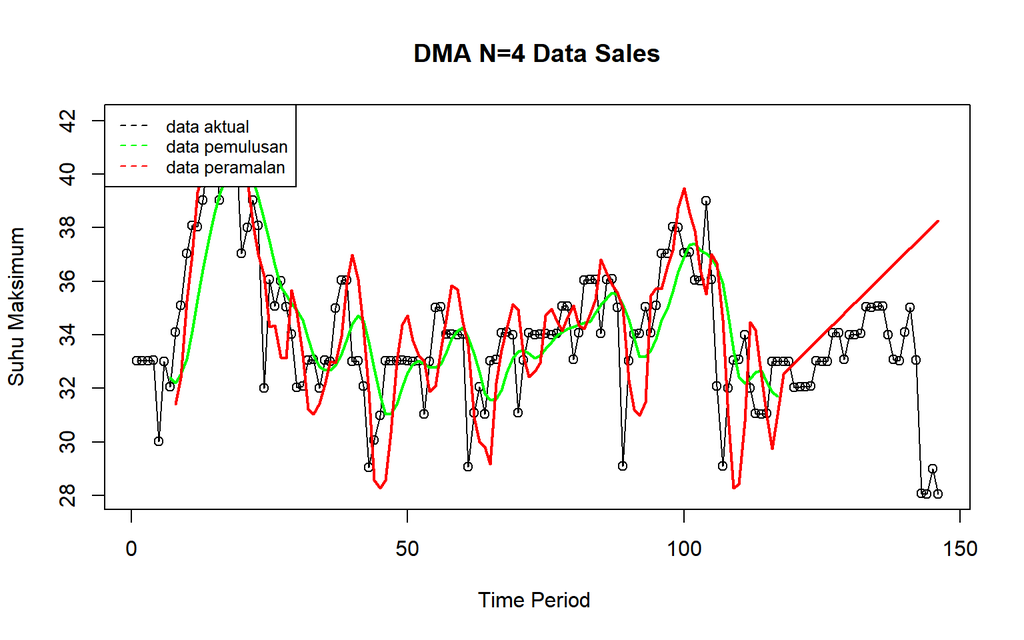

```r
ts.plot(data.ts, xlab="Time Period ", ylab="Suhu Maksimum", main= "DMA N=4 Data Sales")
points(data.ts)
lines(data.gab2[,3],col="green",lwd=2)
lines(data.gab2[,6],col="red",lwd=2)
legend("topleft",c("data aktual","data pemulusan","data peramalan"), lty=8, col=c("black","green","red"), cex=0.8)
```

Selanjutnya perhitungan akurasi dilakukan baik pada data latih maupun data uji. Perhitungan akurasi dilakukan dengan ukuran akurasi SSE, MSE dan MAPE.

```r
#Menghitung nilai keakuratan data latih
error_train.dma = training.ts-data.ramal2[1:length(training.ts)]

SSE_train.dma = sum(error_train.dma[8:length(training.ts)]^2)
MSE_train.dma = mean(error_train.dma[8:length(training.ts)]^2)
MAPE_train.dma = mean(abs((error_train.dma[8:length(training.ts)]/training.ts[8:length(training.ts)])*100))

akurasi_train.dma <- matrix(c(SSE_train.dma, MSE_train.dma, MAPE_train.dma))
row.names(akurasi_train.dma)<- c("SSE", "MSE", "MAPE")
colnames(akurasi_train.dma) <- c("Akurasi m = 4")
akurasi_train.dma
```

```
##      Akurasi m = 4
## SSE     536.298233
## MSE       4.875438
## MAPE      5.252071
```

Perhitungan akurasi pada data latih menggunakan nilai MAPE menghasilkan nilai MAPE yang kurang dari 10% sehingga dikategorikan sangat baik. Selanjutnya, perhitungan nilai akurasi dilakukan pada data uji.

```r
#Menghitung nilai keakuratan data uji
error_test.dma = testing.ts-data.gab2[118:146,6]
SSE_test.dma = sum(error_test.dma^2)
MSE_test.dma = mean(error_test.dma^2)
MAPE_test.dma = mean(abs((error_test.dma/testing.ts*100)))

akurasi_test.dma <- matrix(c(SSE_test.dma, MSE_test.dma, MAPE_test.dma))
row.names(akurasi_test.dma)<- c("SSE", "MSE", "MAPE")
colnames(akurasi_test.dma) <- c("Akurasi m = 4")
akurasi_test.dma
```

```
##      Akurasi m = 4
## SSE     458.229388
## MSE      15.801013
## MAPE      8.534882
```

Perhitungan akurasi menggunakan data latih menghasilkan nilai MAPE yang kurang dari 10% sehingga nilai akurasi ini dapat dikategorikan sebagai sangat baik.

## Single Exponential Smoothing & Double Exponential Smoothing

Metode Exponential Smoothing merupakan metode pemulusan deret waktu dengan memberikan bobot yang menurun secara eksponensial pada data historis, di mana nilai terbaru mendapat bobot lebih besar dibanding nilai yang lebih lama. Metode ini menggunakan satu atau lebih parameter pemulusan yang secara langsung menentukan besar kecilnya bobot setiap pengamatan. Pemilihan parameter yang tepat akan sangat berpengaruh terhadap hasil ramalan. Secara umum, Exponential Smoothing dibedakan menjadi dua jenis, yaitu model tunggal (single) yang digunakan untuk data tanpa tren maupun musiman, serta model ganda (double) yang mampu menangkap adanya tren pada data.

### Pembagian Data

Pembagian data latih dan data uji dilakukan dengan perbandingan 80% data latih dan 20% data uji.

```r
# jumlah baris data
n <- nrow(data)

# hitung batas 80%
n_train <- ceiling(0.8 * n)

# bagi data
training <- data[1:n_train, ]
testing  <- data[(n_train+1):n, ]

# ubah ke time series
train.ts <- ts(training$Suhu)
test.ts  <- ts(testing$Suhu)
```

### Eksplorasi

Eksplorasi dilakukan dengan membuat plot data deret waktu untuk keseluruhan data, data latih, dan data uji.

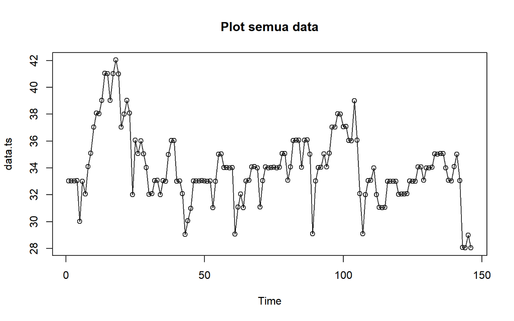

```r
#eksplorasi data
plot(data.ts, col="black",main="Plot semua data")
points(data.ts)
```

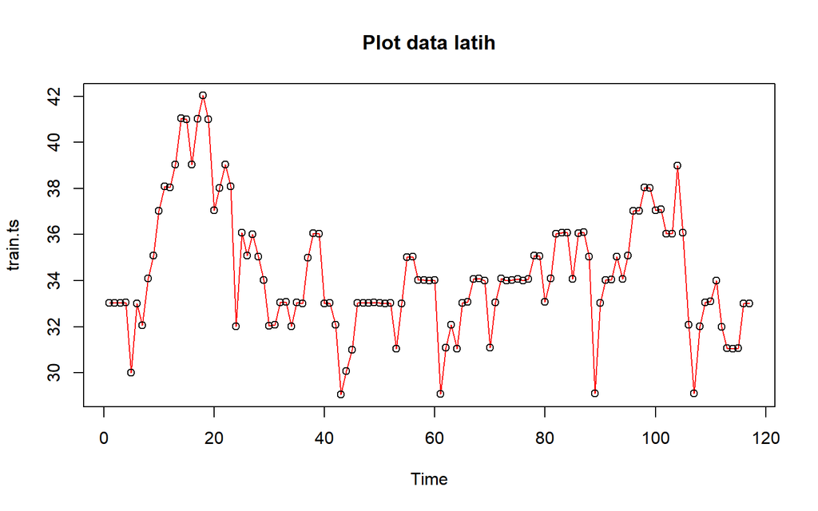

```r
plot(train.ts, col="red",main="Plot data latih")
points(train.ts)
```

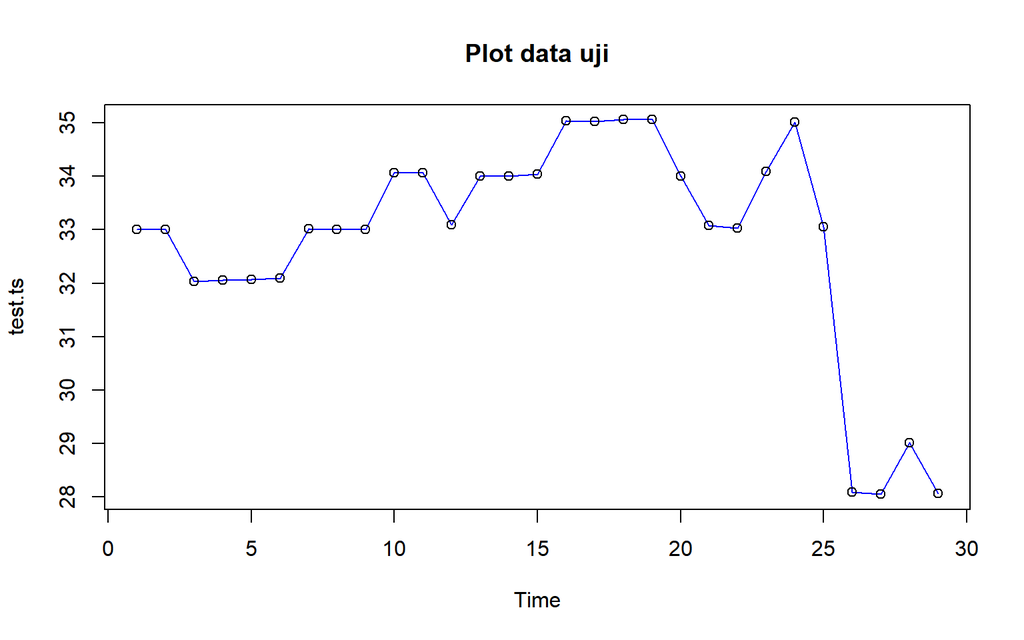

```r
plot(test.ts, col="blue",main="Plot data uji")
points(test.ts)
```

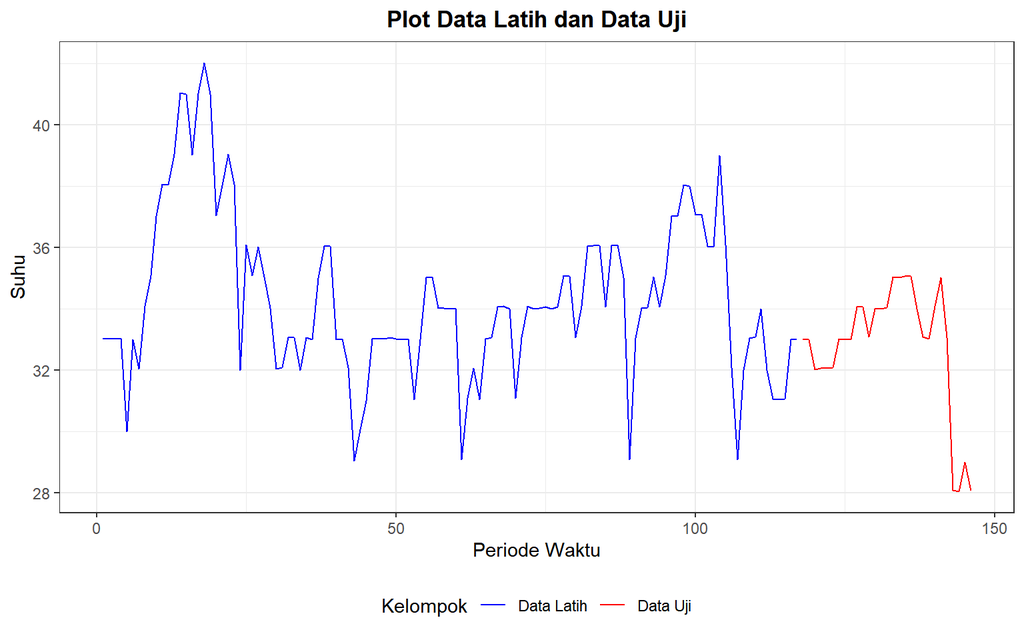

```r
#Eksplorasi dengan GGPLOT
ggplot(data_plot, aes(x = Period, y = Suhu, color = Kelompok)) +
  geom_line() +
  labs(
    x = "Periode Waktu",
    y = "Suhu",
    title = "Plot Data Latih dan Data Uji"
  ) +
  scale_color_manual(
    values = c(
      "Data Latih" = "blue",
      "Data Uji" = "red"
    )
  ) +
  theme_bw() +
  theme(
    legend.position = "bottom",
    plot.title = element_text(
      hjust = 0.5,
      face = "bold"
  )
  )
```

## Single Exponential Smoothing

Single Exponential Smoothing (SES) adalah metode peramalan deret waktu yang dikembangkan untuk mengatasi kelemahan Moving Average. Jika pada Moving Average setiap data periode sebelumnya dianggap memiliki bobot yang sama, maka SES memberikan bobot yang semakin mengecil secara eksponensial terhadap data lama, sehingga data terbaru diberi bobot lebih besar.

Single Exponential Smoothing merupakan metode pemulusan yang tepat digunakan untuk data dengan pola stasioner atau konstan.

Nilai pemulusan pada periode ke-t didapat dari persamaan:

$$\tilde{y}_T=\lambda
y_t+(1-\lambda)\tilde{y}_{T-1}$$

Nilai parameter $\lambda$ adalah nilai antara 0 dan 1.

Nilai pemulusan periode ke-t bertindak sebagai nilai ramalan pada periode ke-$(T+\tau)$.

$$\tilde{y}_{T+\tau}(T)=\tilde{y}_T$$

Pemulusan dengan metode SES dapat dilakukan dengan dua fungsi dari *packages* berbeda, yaitu (1) fungsi `ses()` dari *packages* `forecast` dan (2) fungsi `HoltWinters` dari *packages* `stats` .

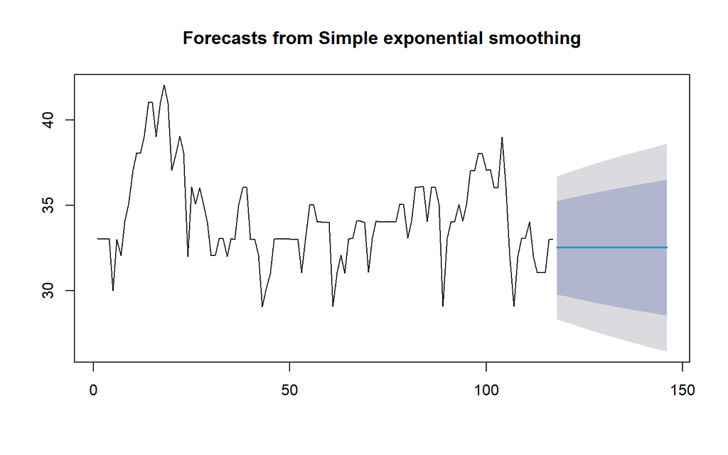

```r
#Cara 1 (fungsi ses)
ses.1 <- ses(train.ts, h = 29, alpha = 0.2)
plot(ses.1)
```

```r
ses.1
```

```
##     Point Forecast    Lo 80    Hi 80    Lo 95    Hi 95
## 118       32.51819 29.79045 35.24593 28.34647 36.68990
## 119       32.51819 29.73643 35.29995 28.26385 36.77252
## 120       32.51819 29.68344 35.35294 28.18281 36.85356
## 121       32.51819 29.63142 35.40496 28.10326 36.93312
## 122       32.51819 29.58032 35.45605 28.02511 37.01126
## 123       32.51819 29.53010 35.50628 27.94830 37.08807
## 124       32.51819 29.48071 35.55567 27.87276 37.16362
## 125       32.51819 29.43210 35.60427 27.79843 37.23795
## 126       32.51819 29.38425 35.65212 27.72525 37.31113
## 127       32.51819 29.33712 35.69925 27.65317 37.38320
## 128       32.51819 29.29068 35.74569 27.58215 37.45423
## 129       32.51819 29.24490 35.79147 27.51213 37.52425
## 130       32.51819 29.19975 35.83663 27.44308 37.59330
## 131       32.51819 29.15521 35.88117 27.37495 37.66143
## 132       32.51819 29.11124 35.92513 27.30771 37.72866
## 133       32.51819 29.06784 35.96854 27.24134 37.79504
## 134       32.51819 29.02498 36.01140 27.17578 37.86059
## 135       32.51819 28.98263 36.05374 27.11102 37.92535
## 136       32.51819 28.94079 36.09558 27.04703 37.98934
## 137       32.51819 28.89943 36.13694 26.98378 38.05260
## 138       32.51819 28.85854 36.17783 26.92124 38.11513
## 139       32.51819 28.81810 36.21827 26.85940 38.17698
## 140       32.51819 28.77810 36.25828 26.79822 38.23816
## 141       32.51819 28.73852 36.29785 26.73769 38.29869
## 142       32.51819 28.69935 36.33702 26.67778 38.35859
## 143       32.51819 28.66058 36.37579 26.61849 38.41789
## 144       32.51819 28.62220 36.41418 26.55978 38.47659
## 145       32.51819 28.58419 36.45219 26.50165 38.53472
## 146       32.51819 28.54654 36.48984 26.44408 38.59230
```

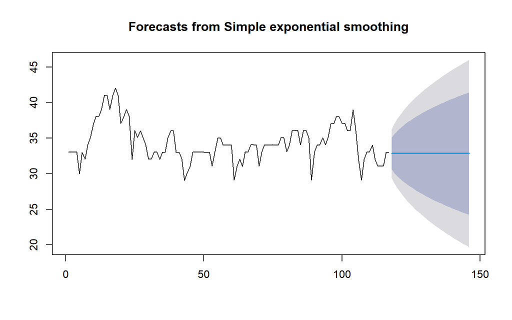

```r
ses.2<- ses(train.ts, h = 29, alpha = 0.7)
plot(ses.2)
```

```r
ses.2
```

```
##     Point Forecast    Lo 80    Hi 80    Lo 95    Hi 95
## 118       32.83573 30.59358 35.07787 29.40666 36.26479
## 119       32.83573 30.09884 35.57262 28.65002 37.02144
## 120       32.83573 29.68075 35.99071 28.01060 37.66085
## 121       32.83573 29.31192 36.35954 27.44652 38.22493
## 122       32.83573 28.97819 36.69326 26.93614 38.73532
## 123       32.83573 28.67112 37.00033 26.46652 39.20494
## 124       32.83573 28.38519 37.28626 26.02922 39.64223
## 125       32.83573 28.11655 37.55490 25.61837 40.05308
## 126       32.83573 27.86240 37.80905 25.22969 40.44177
## 127       32.83573 27.62063 38.05083 24.85992 40.81154
## 128       32.83573 27.38957 38.28188 24.50655 41.16490
## 129       32.83573 27.16793 38.50353 24.16757 41.50388
## 130       32.83573 26.95463 38.71682 23.84137 41.83009
## 131       32.83573 26.74880 38.92265 23.52658 42.14487
## 132       32.83573 26.54971 39.12174 23.22210 42.44936
## 133       32.83573 26.35674 39.31472 22.92697 42.74449
## 134       32.83573 26.16934 39.50211 22.64037 43.03108
## 135       32.83573 25.98708 39.68438 22.36162 43.30983
## 136       32.83573 25.80954 39.86192 22.09010 43.58136
## 137       32.83573 25.63637 40.03508 21.82527 43.84619
## 138       32.83573 25.46728 40.20417 21.56666 44.10479
## 139       32.83573 25.30198 40.36947 21.31385 44.35760
## 140       32.83573 25.14023 40.53122 21.06648 44.60498
## 141       32.83573 24.98181 40.68964 20.82420 44.84726
## 142       32.83573 24.82652 40.84493 20.58670 45.08475
## 143       32.83573 24.67419 40.99727 20.35373 45.31772
## 144       32.83573 24.52465 41.14681 20.12503 45.54643
## 145       32.83573 24.37775 41.29370 19.90037 45.77109
## 146       32.83573 24.23336 41.43809 19.67954 45.99191
```

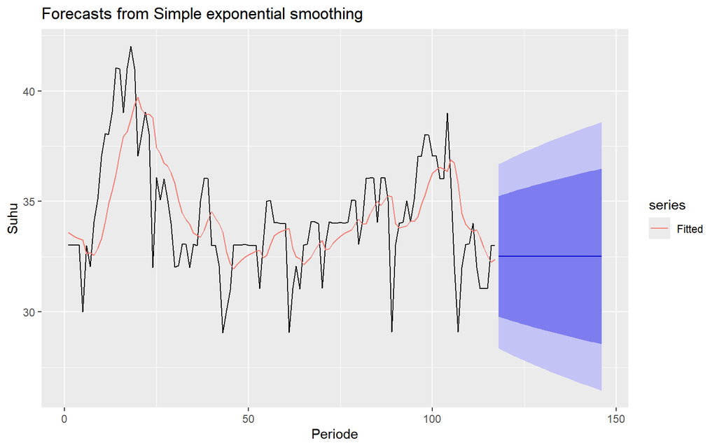

```r
autoplot(ses.1) +
  autolayer(fitted(ses.1), series="Fitted") +
  ylab("Suhu") + xlab("Periode")
```

Selanjutnya akan digunakan fungsi `HoltWinters()` dengan nilai inisialisasi parameter dan panjang periode peramalan yang sama dengan fungsi `ses()` .

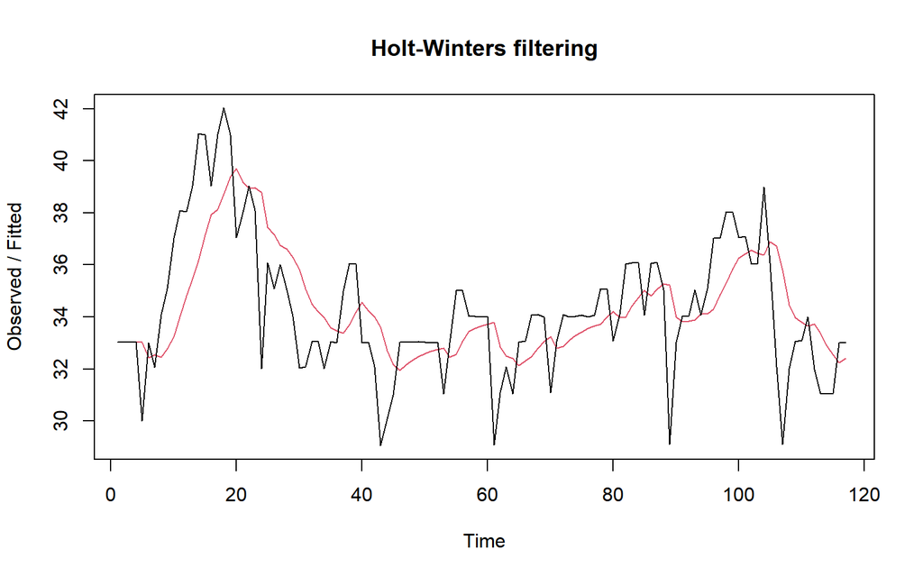

```r
#Cara 2 (fungsi Holtwinter)
ses1<- HoltWinters(train.ts, gamma = FALSE, beta = FALSE, alpha = 0.2)
plot(ses1)
```

```r
#ramalan
ramalan1<- forecast(ses1, h=n_test)
ramalan1
```

```
##     Point Forecast    Lo 80    Hi 80    Lo 95    Hi 95
## 118       32.51819 29.78838 35.24799 28.34331 36.69306
## 119       32.51819 29.73432 35.30205 28.26063 36.77574
## 120       32.51819 29.68129 35.35508 28.17953 36.85684
## 121       32.51819 29.62923 35.40714 28.09992 36.93646
## 122       32.51819 29.57810 35.45828 28.02171 37.01467
## 123       32.51819 29.52784 35.50854 27.94484 37.09153
## 124       32.51819 29.47841 35.55797 27.86924 37.16713
## 125       32.51819 29.42977 35.60661 27.79486 37.24152
## 126       32.51819 29.38188 35.65449 27.72162 37.31475
## 127       32.51819 29.33472 35.70166 27.64949 37.38689
## 128       32.51819 29.28824 35.74814 27.57841 37.45797
## 129       32.51819 29.24242 35.79395 27.50834 37.52804
## 130       32.51819 29.19724 35.83914 27.43923 37.59714
## 131       32.51819 29.15266 35.88372 27.37106 37.66532
## 132       32.51819 29.10866 35.92771 27.30377 37.73260
## 133       32.51819 29.06523 35.97115 27.23734 37.79903
## 134       32.51819 29.02233 36.01404 27.17174 37.86464
## 135       32.51819 28.97996 36.05642 27.10693 37.92944
## 136       32.51819 28.93808 36.09829 27.04289 37.99348
## 137       32.51819 28.89669 36.13968 26.97959 38.05679
## 138       32.51819 28.85577 36.18060 26.91701 38.11937
## 139       32.51819 28.81530 36.22107 26.85511 38.18126
## 140       32.51819 28.77527 36.26111 26.79389 38.24249
## 141       32.51819 28.73566 36.30072 26.73331 38.30306
## 142       32.51819 28.69646 36.33991 26.67336 38.36301
## 143       32.51819 28.65766 36.37871 26.61402 38.42235
## 144       32.51819 28.61925 36.41713 26.55527 38.48110
## 145       32.51819 28.58121 36.45517 26.49710 38.53928
## 146       32.51819 28.54353 36.49284 26.43948 38.59690
```

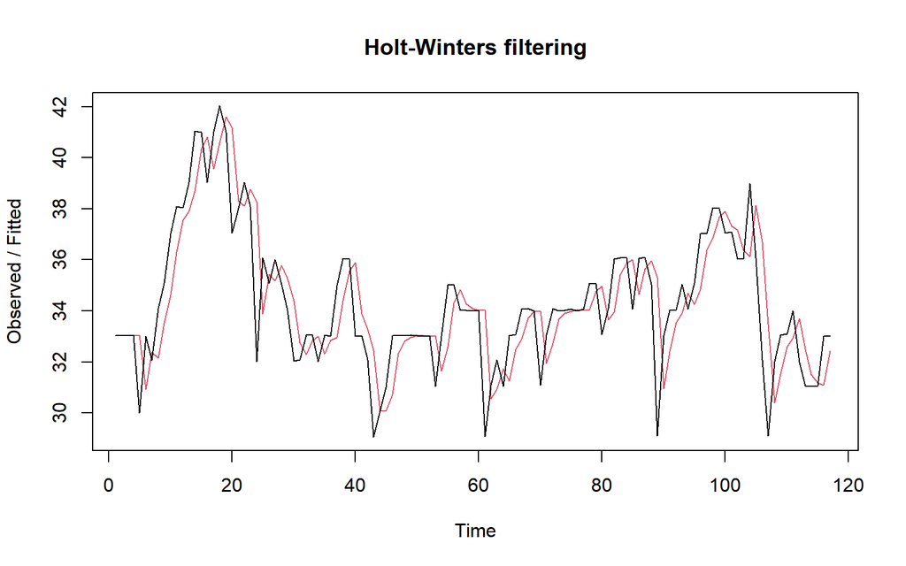

```r
ses2<- HoltWinters(train.ts, gamma = FALSE, beta = FALSE, alpha = 0.7)
plot(ses2)
```

```r
#ramalan
ramalan2<- forecast(ses2, h=n_test)
ramalan2
```

```
##     Point Forecast    Lo 80    Hi 80    Lo 95    Hi 95
## 118       32.83573 30.59358 35.07787 29.40666 36.26479
## 119       32.83573 30.09884 35.57261 28.65002 37.02144
## 120       32.83573 29.68075 35.99071 28.01060 37.66085
## 121       32.83573 29.31192 36.35954 27.44653 38.22493
## 122       32.83573 28.97819 36.69326 26.93614 38.73532
## 123       32.83573 28.67113 37.00033 26.46652 39.20494
## 124       32.83573 28.38519 37.28626 26.02922 39.64223
## 125       32.83573 28.11655 37.55490 25.61838 40.05308
## 126       32.83573 27.86241 37.80905 25.22969 40.44176
## 127       32.83573 27.62063 38.05083 24.85992 40.81153
## 128       32.83573 27.38957 38.28188 24.50655 41.16490
## 129       32.83573 27.16793 38.50352 24.16758 41.50388
## 130       32.83573 26.95463 38.71682 23.84137 41.83008
## 131       32.83573 26.74881 38.92265 23.52658 42.14487
## 132       32.83573 26.54971 39.12174 23.22210 42.44935
## 133       32.83573 26.35674 39.31471 22.92697 42.74448
## 134       32.83573 26.16935 39.50211 22.64038 43.03107
## 135       32.83573 25.98708 39.68437 22.36163 43.30983
## 136       32.83573 25.80954 39.86191 22.09010 43.58135
## 137       32.83573 25.63638 40.03508 21.82527 43.84618
## 138       32.83573 25.46728 40.20417 21.56666 44.10479
## 139       32.83573 25.30198 40.36947 21.31386 44.35759
## 140       32.83573 25.14023 40.53122 21.06648 44.60497
## 141       32.83573 24.98181 40.68964 20.82420 44.84725
## 142       32.83573 24.82652 40.84493 20.58671 45.08474
## 143       32.83573 24.67419 40.99726 20.35374 45.31772
## 144       32.83573 24.52465 41.14680 20.12503 45.54642
## 145       32.83573 24.37775 41.29370 19.90037 45.77108
## 146       32.83573 24.23336 41.43809 19.67955 45.99191
```

Pada fungsi `ses()` , terdapat beberapa argumen yang umum digunakan, yaitu

- `y` : nilai data deret waktu
- `alpha` : parameter pemulusan utama (0–1), mengatur bobot data terbaru vs data lama.
- `beta` : parameter pemulusan tren.
- `gamma` : parameter pemulusan musiman.
- `h` : jumlah periode ke depan yang ingin diramalkan (forecast horizon).

Untuk mendapatkan gambar hasil pemulusan pada data latih dengan fungsi `ses()` , perlu digunakan fungsi `autoplot()` dan `autolayer()` dari *library packages* `ggplot2` .

Fungsi `HoltWinters` memiliki argumen yang sama dengan fungsi `ses()` . Argumen-argumen kedua fungsi dapat dilihat lebih lanjut dengan `?ses()` atau `?HoltWinters` .

Nilai parameter $\alpha$ dari kedua fungsi dapat dioptimalkan menyesuaikan dari *error*-nya paling minimumnya. Caranya adalah dengan membuat parameter $\alpha =$ `NULL` .

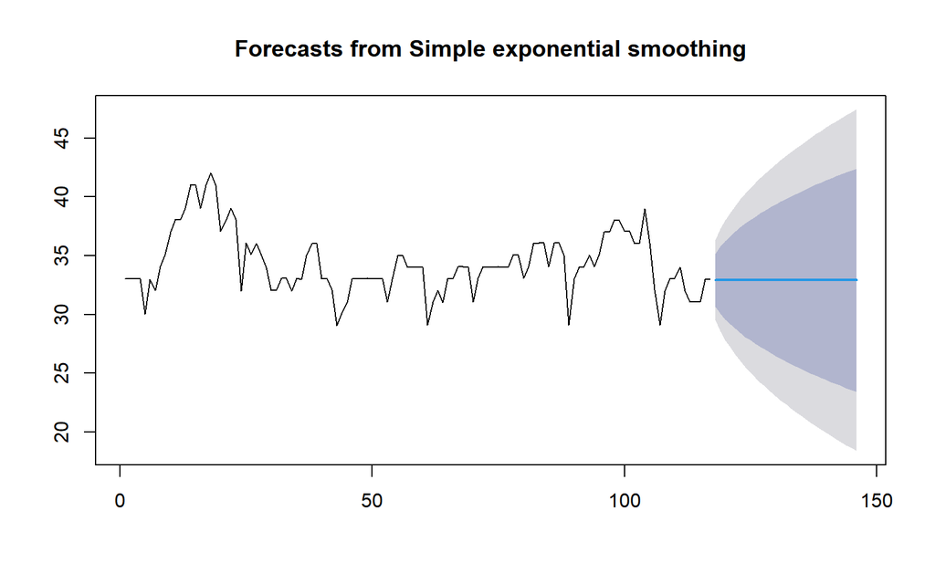

```r
#SES
ses.opt <- ses(train.ts, h = n_test, alpha = NULL)
plot(ses.opt)
```

```r
ses.opt
```

```
##     Point Forecast    Lo 80    Hi 80    Lo 95    Hi 95
## 118       32.91399 30.67655 35.15143 29.49213 36.33586
## 119       32.91399 30.07725 35.75073 28.57557 37.25241
## 120       32.91399 29.58412 36.24387 27.82138 38.00660
## 121       32.91399 29.15513 36.67286 27.16531 38.66268
## 122       32.91399 28.77032 37.05767 26.57679 39.25119
## 123       32.91399 28.41833 37.40966 26.03846 39.78952
## 124       32.91399 28.09196 37.73602 25.53933 40.28865
## 125       32.91399 27.78633 38.04166 25.07190 40.75608
## 126       32.91399 27.49791 38.33007 24.63081 41.19717
## 127       32.91399 27.22410 38.60389 24.21205 41.61594
## 128       32.91399 26.96287 38.86512 23.81253 42.01545
## 129       32.91399 26.71263 39.11535 23.42983 42.39815
## 130       32.91399 26.47211 39.35587 23.06198 42.76600
## 131       32.91399 26.24025 39.58773 22.70738 43.12060
## 132       32.91399 26.01618 39.81180 22.36470 43.46328
## 133       32.91399 25.79916 40.02882 22.03280 43.79518
## 134       32.91399 25.58857 40.23941 21.71073 44.11725
## 135       32.91399 25.38387 40.44411 21.39766 44.43032
## 136       32.91399 25.18459 40.64340 21.09289 44.73510
## 137       32.91399 24.99031 40.83767 20.79577 45.03221
## 138       32.91399 24.80069 41.02729 20.50577 45.32222
## 139       32.91399 24.61540 41.21258 20.22239 45.60559
## 140       32.91399 24.43416 41.39383 19.94520 45.88278
## 141       32.91399 24.25671 41.57128 19.67382 46.15417
## 142       32.91399 24.08282 41.74516 19.40788 46.42010
## 143       32.91399 23.91229 41.91569 19.14708 46.68090
## 144       32.91399 23.74494 42.08304 18.89114 46.93685
## 145       32.91399 23.58058 42.24740 18.63978 47.18821
## 146       32.91399 23.41907 42.40891 18.39277 47.43522
```

```r
#Lamda Optimum Holt Winter
HWopt<- HoltWinters(train.ts, gamma = FALSE, beta = FALSE,alpha = NULL)
HWopt
```

```
## Holt-Winters exponential smoothing without trend and without seasonal component.
##
## Call:
## HoltWinters(x = train.ts, alpha = NULL, beta = FALSE, gamma = FALSE)
##
## Smoothing parameters:
##  alpha: 0.779293
##  beta : FALSE
##  gamma: FALSE
##
## Coefficients:
##       [,1]
## a 32.91391
```

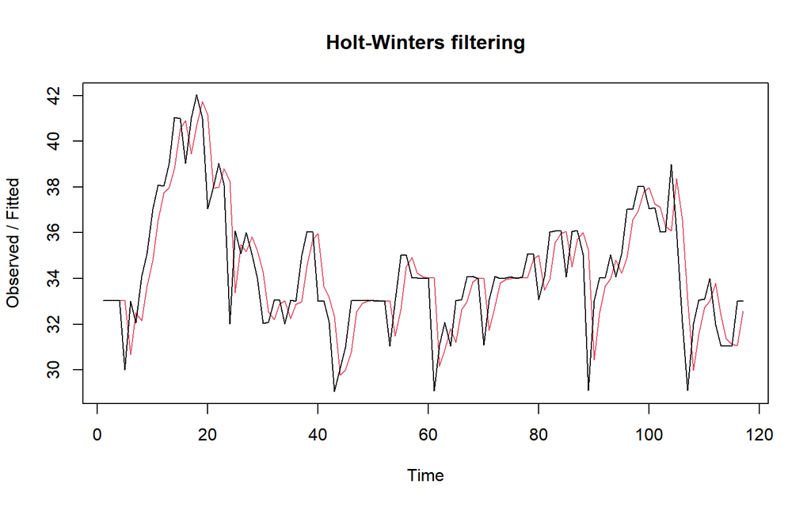

```r
plot(HWopt)
```

```r
#ramalan
ramalanopt<- forecast(HWopt, h=29)
ramalanopt
```

```
##     Point Forecast    Lo 80    Hi 80    Lo 95    Hi 95
## 118       32.91391 30.67647 35.15134 29.49204 36.33577
## 119       32.91391 30.07730 35.75051 28.57570 37.25212
## 120       32.91391 29.58426 36.24355 27.82166 38.00616
## 121       32.91391 29.15535 36.67246 27.16569 38.66212
## 122       32.91391 28.77061 37.05721 26.57728 39.25054
## 123       32.91391 28.41867 37.40914 26.03904 39.78878
## 124       32.91391 28.09236 37.73546 25.53998 40.28783
## 125       32.91391 27.78677 38.04105 25.07262 40.75519
## 126       32.91391 27.49840 38.32942 24.63160 41.19622
## 127       32.91391 27.22462 38.60319 24.21290 41.61492
## 128       32.91391 26.96343 38.86438 23.81344 42.01438
## 129       32.91391 26.71323 39.11458 23.43079 42.39702
## 130       32.91391 26.47274 39.35507 23.06300 42.76482
## 131       32.91391 26.24092 39.58690 22.70845 43.11936
## 132       32.91391 26.01688 39.81094 22.36581 43.46200
## 133       32.91391 25.79989 40.02792 22.03396 43.79385
## 134       32.91391 25.58933 40.23848 21.71194 44.11588
## 135       32.91391 25.38466 40.44316 21.39891 44.42890
## 136       32.91391 25.18540 40.64241 21.09418 44.73364
## 137       32.91391 24.99115 40.83666 20.79710 45.03071
## 138       32.91391 24.80156 41.02626 20.50714 45.32068
## 139       32.91391 24.61629 41.21152 20.22380 45.60402
## 140       32.91391 24.43507 41.39274 19.94665 45.88117
## 141       32.91391 24.25765 41.57017 19.67530 46.15252
## 142       32.91391 24.08379 41.74403 19.40940 46.41841
## 143       32.91391 23.91328 41.91453 19.14864 46.67918
## 144       32.91391 23.74595 42.08187 18.89273 46.93509
## 145       32.91391 23.58162 42.24620 18.64140 47.18642
## 146       32.91391 23.42013 42.40769 18.39442 47.43339
```

Setelah dilakukan peramalan, akan dilakukan perhitungan keakuratan hasil peramalan. Perhitungan akurasi ini dilakukan baik pada data latih dan data uji.

#### Akurasi Data Latih

Perhitungan akurasi data dapat dilakukan dengan cara langsung maupun manual. Secara langsung, nilai akurasi dapat diambil dari objek yang tersimpan pada hasil SES, yaitu *sum of squared errors* (SSE). Nilai akurasi lain dapat dihitung pula dari nilai SSE tersebut.

```r
#Keakuratan Metode
#Pada data training

# SES dengan alpha = 0.2
SSE1<-ses1$SSE
MSE1<-ses1$SSE/length(train.ts)
RMSE1<-sqrt(MSE1)

akurasi1 <- matrix(c(SSE1,MSE1,RMSE1))
row.names(akurasi1)<- c("SSE", "MSE", "RMSE")
colnames(akurasi1) <- c("Akurasi lamda=0.2")
akurasi1
```

```
##      Akurasi lamda=0.2
## SSE         521.840064
## MSE           4.460171
## RMSE          2.111912
```

```r
# SES dengan alpha = 0.7
SSE2<-ses2$SSE
MSE2<-ses2$SSE/length(train.ts)
RMSE2<-sqrt(MSE2)

akurasi2 <- matrix(c(SSE2,MSE2,RMSE2))
row.names(akurasi2)<- c("SSE", "MSE", "RMSE")
colnames(akurasi2) <- c("Akurasi lamda=0.7")
akurasi2
```

```
##      Akurasi lamda=0.7
## SSE         352.009532
## MSE           3.008628
## RMSE          1.734540
```

```r
#Cara Manual
# Alpha = 0.2
fitted1<-ramalan1$fitted
sisaan1<-ramalan1$residuals
head(sisaan1)
```

```
## Time Series:
## Start = 1
## End = 6
## Frequency = 1
## [1]        NA -0.010000 -0.018000  0.015600 -3.027520  0.567984
```

```r
resid1<-training$Suhu-ramalan1$fitted
head(resid1)
```

```
## Time Series:
## Start = 1
## End = 6
## Frequency = 1
## [1]        NA -0.010000 -0.018000  0.015600 -3.027520  0.567984
```

```r
SSE.1=sum(sisaan1[2:length(train.ts)]^2)
SSE.1
```

```
## [1] 521.8401
```

```r
MSE.1 = SSE.1/length(train.ts)
MSE.1
```

```
## [1] 4.460171
```

```r
MAPE.1 = sum(abs(sisaan1[2:length(train.ts)]/train.ts[2:length(train.ts)])*
               100)/length(train.ts)
MAPE.1
```

```
## [1] 4.690826
```

```r
akurasi.1 <- matrix(c(SSE.1,MSE.1,MAPE.1))
row.names(akurasi.1)<- c("SSE", "MSE", "MAPE")
colnames(akurasi.1) <- c("Akurasi lamda=0.2")
akurasi.1
```

```
##      Akurasi lamda=0.2
## SSE         521.840064
## MSE           4.460171
## MAPE          4.690826
```

```r
# Alpha = 0.7
fitted2<-ramalan2$fitted
sisaan2<-ramalan2$residuals
head(sisaan2)
```

```
## Time Series:
## Start = 1
## End = 6
## Frequency = 1
## [1]        NA -0.010000 -0.013000  0.026100 -3.032170  2.080349
```

```r
resid2<-training$Suhu-ramalan2$fitted
head(resid2)
```

```
## Time Series:
## Start = 1
## End = 6
## Frequency = 1
## [1]        NA -0.010000 -0.013000  0.026100 -3.032170  2.080349
```

```r
SSE.2=sum(sisaan2[2:length(train.ts)]^2)
SSE.2
```

```
## [1] 352.0095
```

```r
MSE.2 = SSE.2/length(train.ts)
MSE.2
```

```
## [1] 3.008628
```

```r
MAPE.2 = sum(abs(sisaan2[2:length(train.ts)]/train.ts[2:length(train.ts)])*
               100)/length(train.ts)
MAPE.2
```

```
## [1] 3.67924
```

```r
akurasi.2 <- matrix(c(SSE.2,MSE.2,MAPE.2))
row.names(akurasi.2)<- c("SSE", "MSE", "MAPE")
colnames(akurasi.2) <- c("Akurasi lamda=0.7")
akurasi.2
```

```
##      Akurasi lamda=0.7
## SSE         352.009532
## MSE           3.008628
## MAPE          3.679240
```

Berdasarkan nilai SSE, MSE, RMSE, dan MAPE di antara kedua parameter, nilai parameter $\lambda=0,7$ menghasilkan akurasi yang lebih baik dibanding $\lambda=0,2$ . Hal ini dilihat dari nilai masing-masing ukuran akurasi yang lebih kecil. Berdasarkan nilai MAPE-nya, hasil ini dapat dikategorikan sebagai peramalan sangat baik.

#### Akurasi Data Uji

Akurasi data uji dapat dihitung dengan cara yang hampir sama dengan perhitungan akurasi data latih.

```r
# jumlah observasi uji
n_test <- nrow(testing)

# error (ramalan - aktual), samakan panjang dan tipe numeric
e1   <- as.numeric(ramalan1$mean)[1:n_test] - as.numeric(testing$Suhu)
e2   <- as.numeric(ramalan2$mean)[1:n_test] - as.numeric(testing$Suhu)
eopt <- as.numeric(ramalanopt$mean)[1:n_test] - as.numeric(testing$Suhu)

# SSE / MSE / RMSE untuk masing-masing model (abaikan NA)
SSEtesting1  <- sum(e1^2,  na.rm = TRUE)
MSEtesting1  <- mean(e1^2, na.rm = TRUE)
RMSEtesting1 <- sqrt(MSEtesting1)

SSEtesting2  <- sum(e2^2,  na.rm = TRUE)
MSEtesting2  <- mean(e2^2, na.rm = TRUE)
RMSEtesting2 <- sqrt(MSEtesting2)

SSEtestingopt  <- sum(eopt^2,  na.rm = TRUE)
MSEtestingopt  <- mean(eopt^2, na.rm = TRUE)
RMSEtestingopt <- sqrt(MSEtestingopt)

# Tabel ringkas
akurasitesting_SSE <- matrix(c(SSEtesting1, SSEtesting2, SSEtestingopt),
                             nrow = 3,
                             dimnames = list(c("SSE1","SSE2","SSEopt"), "Nilai"))
akurasitesting_MSE <- matrix(c(MSEtesting1, MSEtesting2, MSEtestingopt),
                             nrow = 3,
                             dimnames = list(c("MSE1","MSE2","MSEopt"), "Nilai"))
akurasitesting_RMSE <- matrix(c(RMSEtesting1, RMSEtesting2, RMSEtestingopt),
                              nrow = 3,
                              dimnames = list(c("RMSE1","RMSE2","RMSEopt"), "Nilai"))

akurasitesting_SSE
```

```
##           Nilai
## SSE1   123.0858
## SSE2   120.1465
## SSEopt 120.3200
```

```r
akurasitesting_MSE
```

```
##           Nilai
## MSE1   4.244337
## MSE2   4.142982
## MSEopt 4.148965
```

```r
akurasitesting_RMSE
```

```
##            Nilai
## RMSE1   2.060179
## RMSE2   2.035432
## RMSEopt 2.036901
```

## *Double Exponential Smoothing* (DES)

Metode pemulusan *Double Exponential Smoothing* (DES) digunakan untuk data yang memiliki pola tren. Metode DES adalah metode semacam SES, hanya saja dilakukan dua kali, yaitu pertama untuk tahapan ‘level’ dan kedua untuk tahapan ‘tren’. Pemulusan menggunakan metode ini akan menghasilkan peramalan tidak konstan untuk periode berikutnya.

Pemulusan dengan metode DES kali ini akan menggunakan fungsi `HoltWinters()` . Jika sebelumnya nilai argumen `beta` dibuat `FALSE` , kali ini argumen tersebut akan diinisialisasi bersamaan dengan nilai `alpha` .

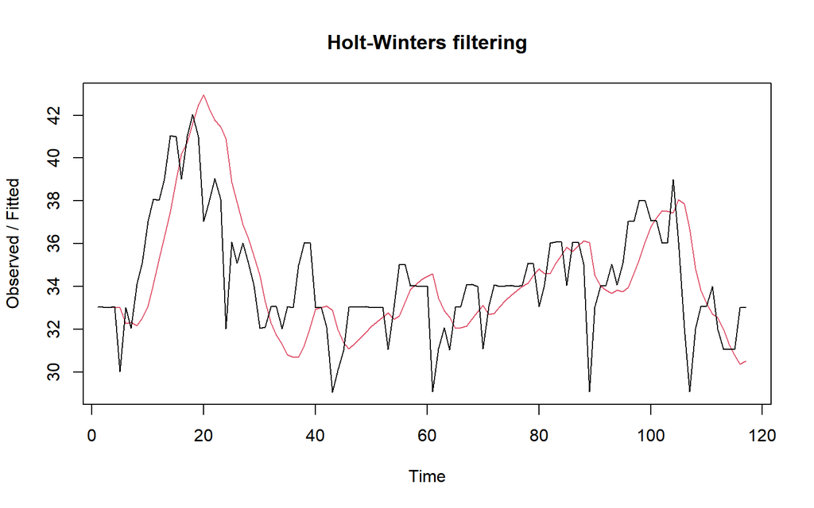

```r
#Lamda=0.2 dan gamma=0.2
des.1<- HoltWinters(train.ts, gamma = FALSE, beta = 0.2, alpha = 0.2)
plot(des.1)
```

```r
#ramalan
ramalandes1<- forecast(des.1, h=29)
ramalandes1
```

```
##     Point Forecast     Lo 80    Hi 80     Lo 95    Hi 95
## 118       30.73234 27.659258 33.80543 26.032465 35.43222
## 119       30.45691 27.296554 33.61726 25.623565 35.29025
## 120       30.18147 26.906071 33.45686 25.172181 35.19075
## 121       29.90603 26.486193 33.32586 24.675842 35.13621
## 122       29.63059 26.036262 33.22492 24.133540 35.12764
## 123       29.35515 25.556440 33.15386 23.545523 35.16478
## 124       29.07971 25.047525 33.11190 22.913013 35.24641
## 125       28.80427 24.510744 33.09780 22.237886 35.37066
## 126       28.52884 23.947567 33.11010 21.522390 35.53528
## 127       28.25340 23.359563 33.14723 20.768923 35.73787
## 128       27.97796 22.748293 33.20762 19.979875 35.97604
## 129       27.70252 22.115248 33.28979 19.157525 36.24751
## 130       27.42708 21.461812 33.39235 18.303989 36.55017
## 131       27.15164 20.789243 33.51404 17.421192 36.88209
## 132       26.87620 20.098675 33.65373 16.510867 37.24154
## 133       26.60077 19.391121 33.81041 15.574566 37.62697
## 134       26.32533 18.667484 33.98317 14.613667 38.03699
## 135       26.04989 17.928566 34.17121 13.629398 38.47038
## 136       25.77445 17.175081 34.37382 12.622850 38.92605
## 137       25.49901 16.407664 34.59036 11.594995 39.40303
## 138       25.22357 15.626883 34.82026 10.546702 39.90044
## 139       24.94813 14.833248 35.06302  9.478750 40.41752
## 140       24.67270 14.027216 35.31818  8.391839 40.95355
## 141       24.39726 13.209201 35.58531  7.286601 41.50791
## 142       24.12182 12.379576 35.86406  6.163608 42.08003
## 143       23.84638 11.538683 36.15408  5.023382 42.66938
## 144       23.57094 10.686832 36.45505  3.866396 43.27549
## 145       23.29550  9.824308 36.76670  2.693089 43.89792
## 146       23.02006  8.951374 37.08876  1.503859 44.53627
```

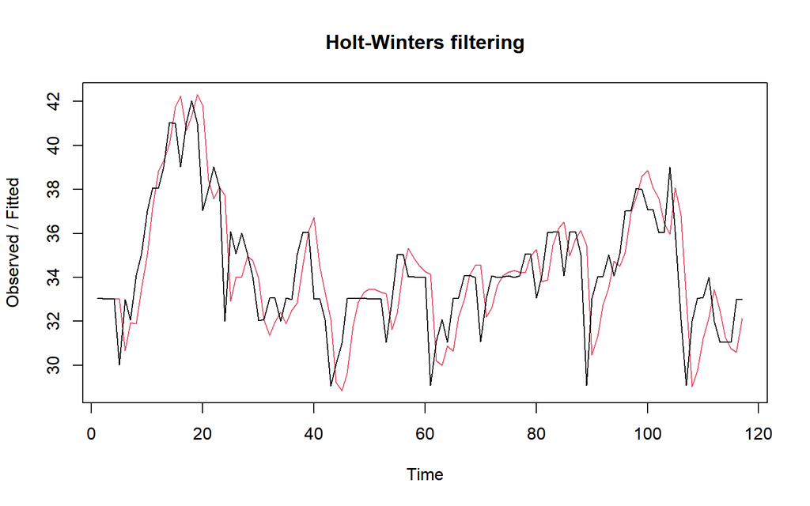

```r
#Lamda=0.6 dan gamma=0.3
des.2<- HoltWinters(train.ts, gamma = FALSE, beta = 0.3, alpha = 0.6)
plot(des.2)
```

```r
#ramalan
ramalandes2<- forecast(des.2, h=29)
ramalandes2
```

```
##     Point Forecast      Lo 80    Hi 80       Lo 95     Hi 95
## 118       32.91416 30.4335484 35.39478  29.1203897  36.70794
## 119       33.16769 30.0217053 36.31367  28.3563219  37.97906
## 120       33.42121 29.4755539 37.36688  27.3868472  39.45558
## 121       33.67474 28.8203329 38.52915  26.2505649  41.09892
## 122       33.92827 28.0727511 39.78378  24.9730290  42.88350
## 123       34.18179 27.2440446 41.11954  23.5714236  44.79216
## 124       34.43532 26.3421195 42.52851  22.0578399  46.81279
## 125       34.68884 25.3728164 44.00487  20.4412105  48.93647
## 126       34.94237 24.3406433 45.54409  18.7284299  51.15630
## 127       35.19589 23.2492095 47.14257  16.9250177  53.46677
## 128       35.44942 22.1014916 48.79734  15.0355264  55.86331
## 129       35.70294 20.9000046 50.50588  13.0638024  58.34208
## 130       35.95647 19.6469146 52.26602  11.0131585  60.89978
## 131       36.20999 18.3441171 54.07587   8.8864935  63.53349
## 132       36.46352 16.9932922 55.93375   6.6863767  66.24066
## 133       36.71704 15.5959446 57.83814   4.4151098  69.01898
## 134       36.97057 14.1534346 59.78770   2.0747730  71.86637
## 135       37.22409 12.6670009 61.78119  -0.3327394  74.78093
## 136       37.47762 11.1377788 63.81746  -2.8056910  77.76093
## 137       37.73115  9.5668147 65.89548  -5.3424815  80.80477
## 138       37.98467  7.9550776 68.01426  -7.9416289  83.91097
## 139       38.23820  6.3034689 70.17292 -10.6017546  87.07815
## 140       38.49172  4.6128301 72.37061 -13.3215717  90.30501
## 141       38.74525  2.8839496 74.60654 -16.0998744  93.59037
## 142       38.99877  1.1175681 76.87998 -18.9355301  96.93307
## 143       39.25230 -0.6856165 79.19021 -21.8274712 100.33207
## 144       39.50582 -2.5249450 81.53659 -24.7746896 103.78634
## 145       39.75935 -4.3997933 83.91849 -27.7762308 107.29493
## 146       40.01287 -6.3095693 86.33532 -30.8311893 110.85694
```

Selanjutnya jika ingin membandingkan plot data latih dan data uji adalah sebagai berikut.

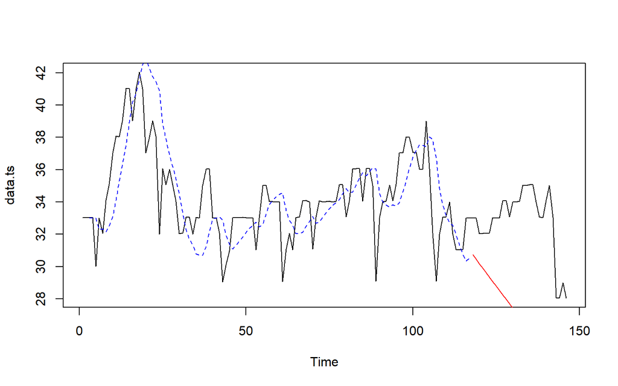

```r
plot(data.ts)
lines(des.1$fitted[,1], lty=2, col="blue")
lines(ramalandes1$mean, col="red")
```

Untuk mendapatkan nilai parameter optimum dari DES, argumen `alpha` dan `beta` dapat dibuat `NULL` seperti berikut.

```r
#Lamda dan gamma optimum
des.opt<- HoltWinters(train.ts, gamma = FALSE)
des.opt
```

```
## Holt-Winters exponential smoothing with trend and without seasonal component.
##
## Call:
## HoltWinters(x = train.ts, gamma = FALSE)
##
## Smoothing parameters:
##  alpha: 0.7793317
##  beta : 0
##  gamma: FALSE
##
## Coefficients:
##       [,1]
## a 32.91111
## b -0.01000
```

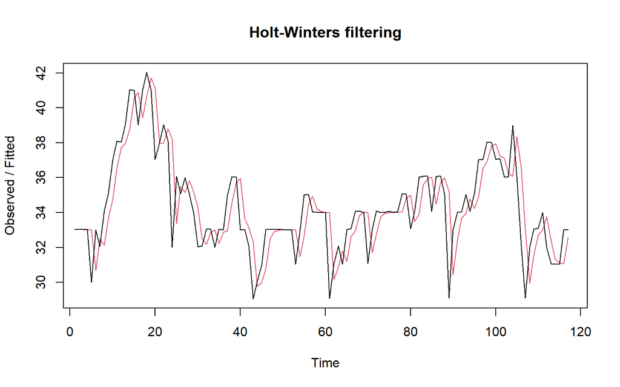

```r
plot(des.opt)
```

```r
#ramalan
ramalandesopt<- forecast(des.opt, h=29)
ramalandesopt
```

```
##     Point Forecast    Lo 80    Hi 80    Lo 95    Hi 95
## 118       32.90111 30.65388 35.14834 29.46427 36.33795
## 119       32.89111 30.04204 35.74018 28.53383 37.24839
## 120       32.88111 29.53680 36.22542 27.76643 37.99579
## 121       32.87111 29.09598 36.64623 27.09755 38.64467
## 122       32.86111 28.69953 37.02269 26.49652 39.22570
## 123       32.85111 28.33603 37.36619 25.94589 39.75633
## 124       32.84111 27.99827 37.68395 25.43462 40.24760
## 125       32.83111 27.68132 37.98089 24.95519 40.70703
## 126       32.82111 27.38167 38.26055 24.50221 41.14001
## 127       32.81111 27.09668 38.52553 24.07165 41.55057
## 128       32.80111 26.82434 38.77788 23.66042 41.94180
## 129       32.79111 26.56303 39.01919 23.26608 42.31614
## 130       32.78111 26.31147 39.25074 22.88666 42.67556
## 131       32.77111 26.06862 39.47360 22.52054 43.02168
## 132       32.76111 25.83359 39.68863 22.16638 43.35584
## 133       32.75111 25.60564 39.89658 21.82306 43.67916
## 134       32.74111 25.38415 40.09807 21.48961 43.99261
## 135       32.73111 25.16856 40.29365 21.16520 44.29702
## 136       32.72111 24.95843 40.48379 20.84911 44.59311
## 137       32.71111 24.75332 40.66890 20.54072 44.88150
## 138       32.70111 24.55288 40.84934 20.23947 45.16275
## 139       32.69111 24.35679 41.02542 19.94488 45.43734
## 140       32.68111 24.16477 41.19744 19.65650 45.70572
## 141       32.67111 23.97656 41.36566 19.37395 45.96827
## 142       32.66111 23.79193 41.53029 19.09687 46.22535
## 143       32.65111 23.61067 41.69155 18.82495 46.47727
## 144       32.64111 23.43260 41.84962 18.55791 46.72431
## 145       32.63111 23.25754 42.00468 18.29547 46.96675
## 146       32.62111 23.08533 42.15689 18.03740 47.20482
```

Selanjutnya akan dilakukan perhitungan akurasi pada data latih maupun data uji dengan ukuran akurasi SSE, MSE dan MAPE.

#### Akurasi Data Latih

```r
#Akurasi Data Training
ssedes.train1<-des.1$SSE
msedes.train1<-ssedes.train1/length(train.ts)
sisaandes1<-ramalandes1$residuals
head(sisaandes1)
```

```
## Time Series:
## Start = 1
## End = 6
## Frequency = 1
## [1]        NA        NA  0.000000  0.040000 -2.999600  0.718704
```

```r
mapedes.train1 <- sum(abs(sisaandes1[3:length(train.ts)]/train.ts[3:length(train.ts)])
                      *100)/length(train.ts)

akurasides.1 <- matrix(c(ssedes.train1,msedes.train1,mapedes.train1))
row.names(akurasides.1)<- c("SSE", "MSE", "MAPE")
colnames(akurasides.1) <- c("Akurasi lamda=0.2 dan gamma=0.2")
akurasides.1
```

```
##      Akurasi lamda=0.2 dan gamma=0.2
## SSE                       655.896865
## MSE                         5.605956
## MAPE                        5.032473
```

```r
ssedes.train2<-des.2$SSE
msedes.train2<-ssedes.train2/length(train.ts)
sisaandes2<-ramalandes2$residuals
head(sisaandes2)
```

```
## Time Series:
## Start = 1
## End = 6
## Frequency = 1
## [1]        NA        NA  0.000000  0.040000 -3.021200  2.328136
```

```r
mapedes.train2 <- sum(abs(sisaandes2[3:length(train.ts)]/train.ts[3:length(train.ts)])
                      *100)/length(train.ts)

akurasides.2 <- matrix(c(ssedes.train2,msedes.train2,mapedes.train2))
row.names(akurasides.2)<- c("SSE", "MSE", "MAPE")
colnames(akurasides.2) <- c("Akurasi lamda=0.6 dan gamma=0.3")
akurasides.2
```

```
##      Akurasi lamda=0.6 dan gamma=0.3
## SSE                       427.140386
## MSE                         3.650773
## MAPE                        4.200754
```

Hasil akurasi dari data latih didapatkan skenario 2 dengan lamda=0.6 dan gamma=0.3 memiliki hasil yang lebih baik. Namun untuk kedua skenario dapat dikategorikan peramalan sangat baik berdasarkan nilai MAPE-nya.

#### Akurasi Data Uji

```r
#Akurasi Data Testing
selisihdes1<-ramalandes1$mean-testing$Suhu
selisihdes1
```

```
## Time Series:
## Start = 118
## End = 146
## Frequency = 1
##  [1]  -2.277656  -2.543095  -1.848533  -2.153972  -2.439411  -2.734849
##  [7]  -3.940288  -4.195726  -4.481165  -5.816603  -6.092042  -5.387480
## [13]  -6.582919  -6.848357  -7.163796  -8.439234  -8.704673  -9.010111
## [19]  -9.285550  -8.510988  -7.856427  -8.081865  -9.417304 -10.622743
## [25]  -8.938181  -4.243620  -4.479058  -5.714497  -5.039935
```

```r
SSEtestingdes1<-sum(selisihdes1^2)
MSEtestingdes1<-SSEtestingdes1/length(testing$Suhu)
MAPEtestingdes1<-sum(abs(selisihdes1/testing$Suhu)*100)/length(testing$Suhu)

selisihdes2<-ramalandes2$mean-testing$Suhu
selisihdes2
```

```
## Time Series:
## Start = 118
## End = 146
## Frequency = 1
##  [1] -0.09583584  0.16768950  1.39121483  1.61474017  1.85826551  2.09179084
##  [7]  1.41531618  1.68884151  1.93236685  1.12589219  1.37941752  2.61294286
## [13]  1.94646819  2.20999353  2.42351886  1.67704420  1.94056954  2.16409487
## [19]  2.41762021  3.72114554  4.90467088  5.20819621  4.40172155  3.72524689
## [25]  5.93877222 11.16229756 11.45582289 10.74934823 11.95287357
```

```r
SSEtestingdes2<-sum(selisihdes2^2)
MSEtestingdes2<-SSEtestingdes2/length(testing$Suhu)
MAPEtestingdes2<-sum(abs(selisihdes2/testing$Suhu)*100)/length(testing$Suhu)

selisihdesopt<-ramalandesopt$mean-testing$Suhu
selisihdesopt
```

```
## Time Series:
## Start = 118
## End = 146
## Frequency = 1
##  [1] -0.1088909 -0.1088909  0.8511091  0.8111091  0.7911091  0.7611091
##  [7] -0.1788909 -0.1688909 -0.1888909 -1.2588909 -1.2688909 -0.2988909
## [13] -1.2288909 -1.2288909 -1.2788909 -2.2888909 -2.2888909 -2.3288909
## [19] -2.3388909 -1.2988909 -0.3788909 -0.3388909 -1.4088909 -2.3488909
## [25] -0.3988909  4.5611091  4.5911091  3.6211091  4.5611091
```

```r
SSEtestingdesopt<-sum(selisihdesopt^2)
MSEtestingdesopt<-SSEtestingdesopt/length(testing$Suhu)
MAPEtestingdesopt<-sum(abs(selisihdesopt/testing$Suhu)*100)/length(testing$Suhu)

akurasitestingdes <-
  matrix(c(SSEtestingdes1,MSEtestingdes1,MAPEtestingdes1,SSEtestingdes2,MSEtestingdes2,
           MAPEtestingdes2,SSEtestingdesopt,MSEtestingdesopt,MAPEtestingdesopt),
         nrow=3,ncol=3)
row.names(akurasitestingdes)<- c("SSE", "MSE", "MAPE")
colnames(akurasitestingdes) <- c("des ske1","des ske2","des opt")
akurasitestingdes
```

```
##        des ske1  des ske2    des opt
## SSE  1219.29675 710.45099 117.424711
## MSE    42.04472  24.49831   4.049128
## MAPE   17.97640  11.69018   4.737181
```

#### Perbandingan SES dan DES

```r
MSEfull <-
  matrix(c(MSEtesting1,MSEtesting2,MSEtestingopt,MSEtestingdes1,MSEtestingdes2,
           MSEtestingdesopt),nrow=3,ncol=2)
row.names(MSEfull)<- c("ske 1", "ske 2", "ske opt")
colnames(MSEfull) <- c("ses","des")
MSEfull
```

```
##              ses       des
## ske 1   4.244337 42.044715
## ske 2   4.142982 24.498310
## ske opt 4.148965  4.049128
```

# 3. Kesimpulan